# CH5 : Desion Trees & Rondom Forests

# Question 17

Construct a final plot to compare the four trained models

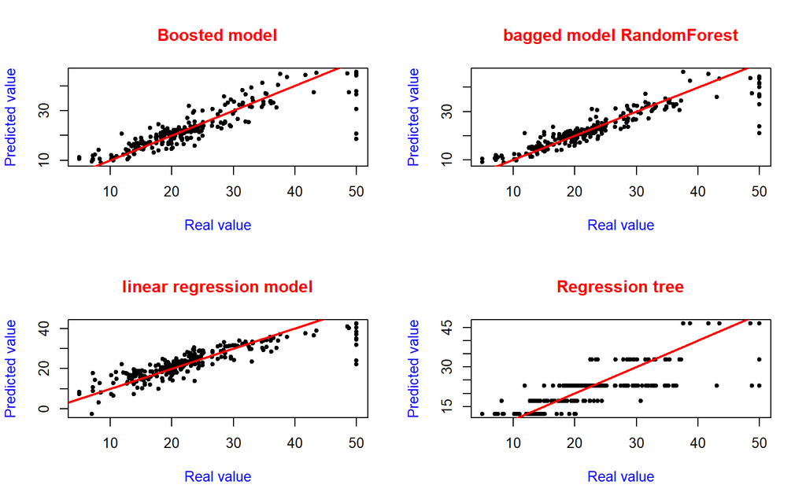

```r
par(mfrow=c(2,2))


#model boost
#modelboost = gbm(medv~.,data = Boston_train)
#predictboost = predict(modelboost,Boston_test,importance = TRUE)
plot(Boston_test$medv,predictboost,
     main = "Boosted model",
     xlab = "Real value",
     ylab = "Predicted value",
     col.main="red",
     col.lab="blue",
     pch = 20)
abline(0,1,lwd=2,col='red')


#bagged model, using the randomForest()
#model2=randomForest(medv~.,Boston_train,importance=TRUE)
#prediction2=predict(model2,Boston_test)
plot(Boston_test$medv,prediction2,
     main = "bagged model RandomForest",
     xlab = "Real value",
     ylab = "Predicted value",
     col.main="red",
     col.lab="blue",
     pch = 20)
abline(0,1,lwd=2,col='red')

#linear regression model
#regmodel = glm(medv~., data = Boston_train)
#predictreg <- predict(regmodel, Boston_test)
plot(Boston_test$medv,predictreg,
     main = "linear regression model",
     xlab = "Real value",
     ylab = "Predicted value",
     col.main="red",
     col.lab="blue",
     pch = 20)
abline(0,1,lwd=2,col='red')

#regression tree to the training data using the rpart() function
#Boston_tree = rpart(medv~.,Boston_train)
#prediction <- predict(Boston_tree, Boston_test)
plot(Boston_test$medv,prediction,
     main = "Regression tree",
     xlab = "Real value",
     ylab = "Predicted value",
     col.main="red",
     col.lab="blue",
     pch = 20)
abline(0,1,lwd=2,col='red')
```

# XGBoost : Extreme Gradient Boosting

> XGBoost is an optimized distributed gradient boosting library designed to be highly efficient, flexible and portable. It implements machine learning algorithms under the Gradient Boosting framework. XGBoost provides a parallel tree boosting (also known as GBDT, GBM) that solve many data science problems in a fast and accurate way. Since its introduction, this algorithm has not only been credited with winning numerous Kaggle competitions but also for being the driving force under the hood for several cutting-edge industry applications

```r
library(xgboost)
library(caret)
indexes = createDataPartition(Boston$medv, p = .85, list = F)
train = Boston[indexes, ]
test = Boston[-indexes, ]

train_x = data.matrix(train[, -13])
train_y = train[,13]

test_x = data.matrix(test[, -13])
test_y = test[, 13]

xgb_train = xgb.DMatrix(data = train_x, label = train_y)
xgb_test = xgb.DMatrix(data = test_x, label = test_y)

xgbc = xgboost(data = xgb_train, max.depth = 2, nrounds = 50)
print(xgbc)
```

```
## ##### xgb.Booster
## raw: 47.4 Kb
## call:
##   xgb.train(params = params, data = dtrain, nrounds = nrounds,
##     watchlist = watchlist, verbose = verbose, print_every_n = print_every_n,
##     early_stopping_rounds = early_stopping_rounds, maximize = maximize,
##     save_period = save_period, save_name = save_name, xgb_model = xgb_model,
##     callbacks = callbacks, max.depth = 2)
## params (as set within xgb.train):
##   max_depth = "2", validate_parameters = "1"
## xgb.attributes:
##   niter
## callbacks:
##   cb.print.evaluation(period = print_every_n)
##   cb.evaluation.log()
## # of features: 13
## niter: 50
## nfeatures : 13
## evaluation_log:
##     iter train_rmse
##        1  10.302251
##        2   7.744468
## ---
##       49   1.997646
##       50   1.980370
```

```r
Boston_xgboost_pred = predict(xgbc, xgb_test)

RMSE(Boston_xgboost_pred, test_y)
```

```
## [1] 3.241878
```

# Classification tree

A classification tree is very similar to a regression tree, except that the classification tree is used to predict a qualitative response rather than a quantitative one. Recall that for a regression tree, the predicted response for an observation is given by the mean response of the training observations that belong to the same terminal node. In contrast, for a classification tree, we predict that each observation belongs to the most commonly occurring class of training observations in the region to which it belongs.

# Question 18

For the rest of this PW, you must: Import the spam dataset and explore it. Be aware that it is preferable that the response column is of type factor. Split the dataset into training and test sets (choose your own seed when using set.seed()). Fit (using rpart and gbm packages):

A Logistic regression model. A simple classification tree. Bagging, Random Forests, Boosting models. For each model, predict the response on the test set and evaluate the performance of the model, using the prediction accuracy (create a function that returns the accuracy for two binary vectors).

```r
df <- read.csv("C:/Users/Papa/Documents/spam.csv")
set.seed(123)

library(ipred) #for bagging()

#convert all_star column to 1s and 0s
df$spam <- as.integer(as.logical(df$spam))

summary(df)
```

```
##       spam            make           address            all
##  Min.   :0.000   Min.   :0.0000   Min.   : 0.000   Min.   :0.0000
##  1st Qu.:0.000   1st Qu.:0.0000   1st Qu.: 0.000   1st Qu.:0.0000
##  Median :0.000   Median :0.0000   Median : 0.000   Median :0.0000
##  Mean   :0.394   Mean   :0.1046   Mean   : 0.213   Mean   :0.2807
##  3rd Qu.:1.000   3rd Qu.:0.0000   3rd Qu.: 0.000   3rd Qu.:0.4200
##  Max.   :1.000   Max.   :4.5400   Max.   :14.280   Max.   :5.1000
##       X3d                our               over            remove
##  Min.   : 0.00000   Min.   : 0.0000   Min.   :0.0000   Min.   :0.0000
##  1st Qu.: 0.00000   1st Qu.: 0.0000   1st Qu.:0.0000   1st Qu.:0.0000
##  Median : 0.00000   Median : 0.0000   Median :0.0000   Median :0.0000
##  Mean   : 0.06542   Mean   : 0.3122   Mean   :0.0959   Mean   :0.1142
##  3rd Qu.: 0.00000   3rd Qu.: 0.3800   3rd Qu.:0.0000   3rd Qu.:0.0000
##  Max.   :42.81000   Max.   :10.0000   Max.   :5.8800   Max.   :7.2700
##     internet           order              mail            receive
##  Min.   : 0.0000   Min.   :0.00000   Min.   : 0.0000   Min.   :0.00000
##  1st Qu.: 0.0000   1st Qu.:0.00000   1st Qu.: 0.0000   1st Qu.:0.00000
##  Median : 0.0000   Median :0.00000   Median : 0.0000   Median :0.00000
##  Mean   : 0.1053   Mean   :0.09007   Mean   : 0.2394   Mean   :0.05982
##  3rd Qu.: 0.0000   3rd Qu.:0.00000   3rd Qu.: 0.1600   3rd Qu.:0.00000
##  Max.   :11.1100   Max.   :5.26000   Max.   :18.1800   Max.   :2.61000
##       will            people            report           addresses
##  Min.   :0.0000   Min.   :0.00000   Min.   : 0.00000   Min.   :0.0000
##  1st Qu.:0.0000   1st Qu.:0.00000   1st Qu.: 0.00000   1st Qu.:0.0000
##  Median :0.1000   Median :0.00000   Median : 0.00000   Median :0.0000
##  Mean   :0.5417   Mean   :0.09393   Mean   : 0.05863   Mean   :0.0492
##  3rd Qu.:0.8000   3rd Qu.:0.00000   3rd Qu.: 0.00000   3rd Qu.:0.0000
##  Max.   :9.6700   Max.   :5.55000   Max.   :10.00000   Max.   :4.4100
##       free            business          email             you
##  Min.   : 0.0000   Min.   :0.0000   Min.   :0.0000   Min.   : 0.000
##  1st Qu.: 0.0000   1st Qu.:0.0000   1st Qu.:0.0000   1st Qu.: 0.000
##  Median : 0.0000   Median :0.0000   Median :0.0000   Median : 1.310
##  Mean   : 0.2488   Mean   :0.1426   Mean   :0.1847   Mean   : 1.662
##  3rd Qu.: 0.1000   3rd Qu.:0.0000   3rd Qu.:0.0000   3rd Qu.: 2.640
##  Max.   :20.0000   Max.   :7.1400   Max.   :9.0900   Max.   :18.750
##      credit              your              font              X000
##  Min.   : 0.00000   Min.   : 0.0000   Min.   : 0.0000   Min.   :0.0000
##  1st Qu.: 0.00000   1st Qu.: 0.0000   1st Qu.: 0.0000   1st Qu.:0.0000
##  Median : 0.00000   Median : 0.2200   Median : 0.0000   Median :0.0000
##  Mean   : 0.08558   Mean   : 0.8098   Mean   : 0.1212   Mean   :0.1016
```

[output cut: 50 more lines]

```
##  Max.   :10.00000   Max.   :4.38500   Max.   :9.752   Max.   :4.08100
##      ch..3             ch..4             ch..5             crl.ave
##  Min.   : 0.0000   Min.   :0.00000   Min.   : 0.00000   Min.   :   1.000
##  1st Qu.: 0.0000   1st Qu.:0.00000   1st Qu.: 0.00000   1st Qu.:   1.588
##  Median : 0.0000   Median :0.00000   Median : 0.00000   Median :   2.276
##  Mean   : 0.2691   Mean   :0.07581   Mean   : 0.04424   Mean   :   5.191
##  3rd Qu.: 0.3150   3rd Qu.:0.05200   3rd Qu.: 0.00000   3rd Qu.:   3.706
##  Max.   :32.4780   Max.   :6.00300   Max.   :19.82900   Max.   :1102.500
##     crl.long          crl.tot
##  Min.   :   1.00   Min.   :    1.0
##  1st Qu.:   6.00   1st Qu.:   35.0
##  Median :  15.00   Median :   95.0
##  Mean   :  52.17   Mean   :  283.3
##  3rd Qu.:  43.00   3rd Qu.:  266.0
##  Max.   :9989.00   Max.   :15841.0
```

```r
str(df)
```

```
## 'data.frame':    4601 obs. of  58 variables:
##  $ spam      : int  1 1 1 1 1 1 1 1 1 1 ...
##  $ make      : num  0 0.21 0.06 0 0 0 0 0 0.15 0.06 ...
##  $ address   : num  0.64 0.28 0 0 0 0 0 0 0 0.12 ...
##  $ all       : num  0.64 0.5 0.71 0 0 0 0 0 0.46 0.77 ...
##  $ X3d       : num  0 0 0 0 0 0 0 0 0 0 ...
##  $ our       : num  0.32 0.14 1.23 0.63 0.63 1.85 1.92 1.88 0.61 0.19 ...
##  $ over      : num  0 0.28 0.19 0 0 0 0 0 0 0.32 ...
##  $ remove    : num  0 0.21 0.19 0.31 0.31 0 0 0 0.3 0.38 ...
##  $ internet  : num  0 0.07 0.12 0.63 0.63 1.85 0 1.88 0 0 ...
##  $ order     : num  0 0 0.64 0.31 0.31 0 0 0 0.92 0.06 ...
##  $ mail      : num  0 0.94 0.25 0.63 0.63 0 0.64 0 0.76 0 ...
##  $ receive   : num  0 0.21 0.38 0.31 0.31 0 0.96 0 0.76 0 ...
##  $ will      : num  0.64 0.79 0.45 0.31 0.31 0 1.28 0 0.92 0.64 ...
##  $ people    : num  0 0.65 0.12 0.31 0.31 0 0 0 0 0.25 ...
```

[output cut: 44 more lines]

```r
sample = sample(c(TRUE, FALSE), nrow(df), replace=TRUE, prob=c(0.7,0.3))

#training_data = df[split,]
#testing_data = df[-split,]
training_data = df[sample, ]
testing_data = df[!sample, ]


model_logistic_classification_tree=model <- glm(spam~. , family="binomial", data=training_data)
model_classification_tree = rpart(spam~. , data=training_data)
model_Bagging = bagging(spam~. , data=training_data)
model_Random_Forest=randomForest(spam~. , data=training_data)
model_boosting=gbm(spam~. , data=training_data)
```

```
## Distribution not specified, assuming bernoulli ...
```

```r
prediction_model_logistic_classification_tree=predict(model_logistic_classification_tree,testing_data)
RMSE(testing_data$spam,prediction_model_logistic_classification_tree)
```

```
## [1] 35.19206
```

```r
prediction_model_classification_tree=predict(model_classification_tree,testing_data)
RMSE(testing_data$spam,prediction_model_classification_tree)
```

```
## [1] 0.3034362
```

```r
prediction_model_Random_Forest=predict(model_Random_Forest,testing_data)
RMSE(testing_data$spam,prediction_model_Random_Forest)
```

```
## [1] 0.2181274
```

```r
prediction_model_Bagging=predict(model_Bagging,testing_data)
RMSE(testing_data$spam,prediction_model_Bagging)
```

```
## [1] 0.2711668
```

```r
prediction_model_boosting=predict(model_boosting,testing_data)
```

```
## Using 100 trees...
```

```r
RMSE(testing_data$spam,prediction_model_boosting)
```

```
## [1] 2.4966
```

# Tuning tree

So far in this PW, we fit bagging, boosting and random forest models, but did not tune any of them, we simply used certain, somewhat arbitrary, parameters. Actually, to make these models better the parameters should be tuned. The parameters include:

Bagging: Actually just a subset of Random Forest with mtry = p. Random Forest: mtry *Boosting: n.trees, interaction.depth, shrinkage, n.minobsinnode

The caret package provides excellent functions to accomplish this. Note that with these tree-based ensemble methods there are two resampling solutions for tuning the model:

Out of Bag Cross-Validation Using Out of Bag samples is advantageous with these methods as compared to Cross-Validation since it removes the need to refit the model and is thus much more computationally efficient. Unfortunately OOB methods cannot be used with gbm models. See the caret documentation for details

# Question 19

19. Use the caret functions to tune your trained models

```r
#install.packages(caret)
# Load the caret package
library(caret)

# See available algorithms in caret
modelnames <- paste(names(getModelInfo()), collapse=',  ')
modelnames
```

```
## [1] "ada,  AdaBag,  AdaBoost.M1,  adaboost,  amdai,  ANFIS,  avNNet,  awnb,  awtan,  bag,  bagEarth,  bagEarthGCV,  bagFDA,  bagFDAGCV,  bam,  bartMachine,  bayesglm,  binda,  blackboost,  blasso,  blassoAveraged,  bridge,  brnn,  BstLm,  bstSm,  bstTree,  C5.0,  C5.0Cost,  C5.0Rules,  C5.0Tree, …
```